# SQL for R via SQLDF

### GROUP BY (grouping columns), HAVING, and ORDER BY

We progress into more complicated and perhaps more useful SQL queries. We have filtered our columns and our rows, now we will group our columns. Before proceeding it is important to note that these clauses do not all have to go in one SQL query, we use the components of the SQL skeleton command as needed. As a reminder the general structure of the SQL query we have learned so far is:

```r
select col1,col2... from table1,table2.. where CONDITION1,CONDITION2..
```

We will now add on to this query and our general structure will be:

```r
select col1,col2... from table1,table2.. where CONDITION1,CONDITION2.. group by col3, having CONDITION3 order by
CONDITION4 ASC|DESC
```

The GROUP BY clauses groups columns, the HAVING clause is similar to the WHERE clause except that it is now used with the aggregate function GROUP BY, and finally the ORDER BY clause is used to sort the result-set (or columns) by descending or ascending order. Back to our example, suppose we wanted to know how many items of each brand we had in our inventory. In order to query that result we want to use the GROUP BY clause to group all the items under a “brand” (a column) and keep a count of them. SQL has several [functions](https://www.w3schools.com/sql/sql_count_avg_sum.asp) that are imposed to columns. In our scenario, we will make use of the count() function that returns the number of rows that match our criteria, the brand. If we run the following query:

```r
select count(brand), brand from clothing GROUP BY brand;
```

The following is returned:

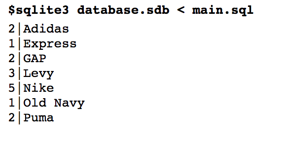

where the query groups columns with the same brand, proceeds to count the aggregate columns and return that selection. Similarly, we could have grouped our columns or any other column like “size” or “gender”. (Note: the GROUP BY clause is very similar to group_by() from the “dplyr” package).

We proceed to slowly build up our (elegant) query and impose a condition on our aggregate query. Suppose now that we want to query the brands that have less than or equal to 2 items in our inventory. (Who knows we might find a rare and expensive piece of clothing or an unusual brand). We again, add to our query the HAVING clause followed by a condition, where our condition here is: count(brand) <= 2

```r
select count(brand), brand from clothing group by brand HAVING COUNT(brand) <=2;
```

The following is returned:

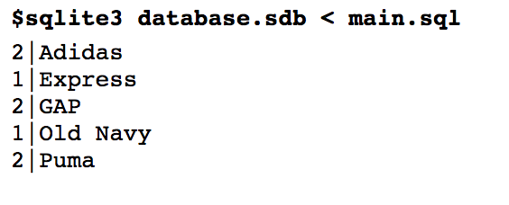

As a reminder the HAVING clause is not necessary to proceed with the aggregate query [by aggregate query I am referring to the joining of columns under the GROUP BY clause], it is a clause that helps to narrow down the data that you are trying to fetch. The HAVING clause does not have to be condition on the columns that are selected, it can be on any column as long as it is part of the aggregate query and can use the aforementioned SQL [functions](https://www.w3schools.com/sql/sql_count_avg_sum.asp). However, it is important to note that the HAVING clause is not a direct substitute of the WHERE clause, the HAVING clause is used as a direct result of the aggregating cause by the GROUP BY clause. To finalize our basic SQL querying, we will add to our query an ORDER BY clause that is independent from the previous aggregation. That is, we can utilize the ORDER BY CLAUSE in a query as simple as:

```r
select * from shoes ORDER BY brand, price;
```

resulting in the following:

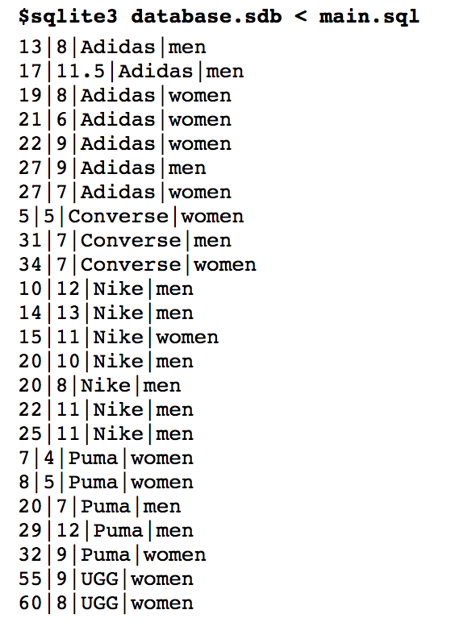

Which orders our query by first the brand (in alphabetical order) and then into price. Now if we wanted to list either (or both) the brand and price by a certain order (ASCENDING or DESCENDING) we can with the DESC and ASC key words:

```r
select * from shoes ORDER BY brand DESC, price ASC;
```

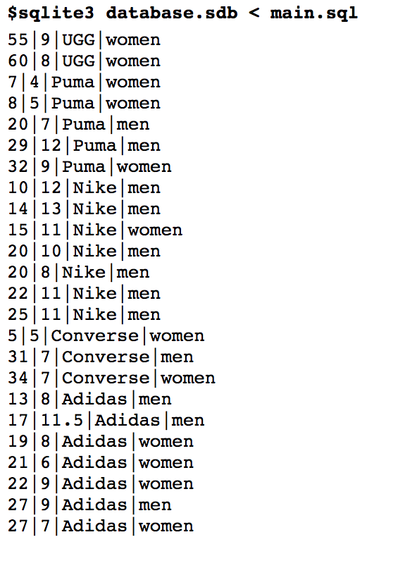

```r
SELECT count(brand), brand FROM clothing GROUP BY brand HAVING count(brand) >= 2 ORDER by count(brand) DESC;
```

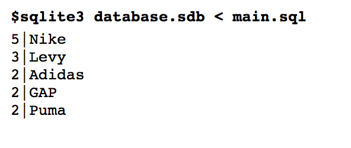

### Joins

A key utility of SQL is the ability to query data by joining tables. For a more complete overview of SQL joins [here](https://www.w3schools.com/sql/sql_join.asp) is a good source. We will use the following graphic as reference.

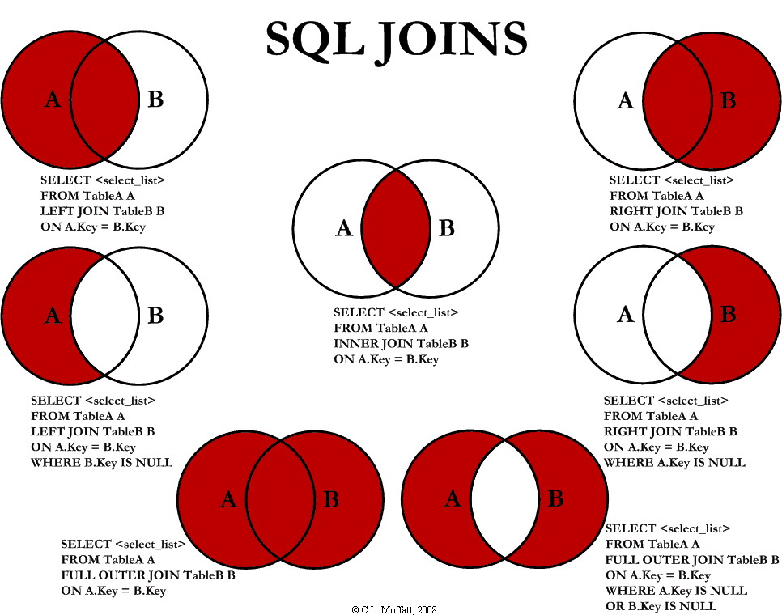

As shown above in the Venn Diagrams there are multiple types of joins in SQL. For simplicity we will only be focusing on the Right Join illustrated at the top most of the reference image. Supposed we have two tables one of our “clothing” inventory and a new table “transactions” with columns “purchaseDate”, “price”, “item”, “itemID”. The “transactions” table keeps track of what items have been sold, when, the price they were sold for, and all items have a unique itemID. From our previous examples, we have also modified the “clothing” table to include an “itemID” for each item. The itemID’s for both tables correspond to the same items. Now, suppose we wanted to know which items have been sold. We have a table that keeps track of our inventory and another of the transactions so how can we go about JOINING these two tables to query what we want? Taking a look at the top right most Venn Diagram, we see that when A and B are joined with RIGHT JOIN the rows that are queried back are those that are part of B and those where B and A intersect. Back to our example, A would be the “clothing” table and B would be the “transactions” table since we don’t want to query items in A that are not in B, or items that have not been sold.

The construction of our “transactions” table and our new “clothing” table:

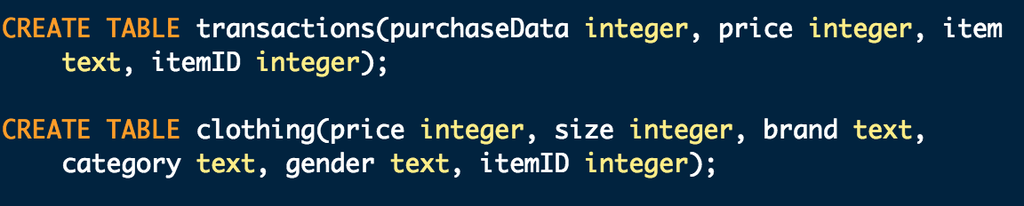

Now suppose the tables were filled accordingly and we ran the following query:

```r
select * from clothing  RIGHT JOIN transactions B where A.itemID = B.itemID;
```

[Note: In this particular example, INNER JOIN would have also worked!]

## SQL in R

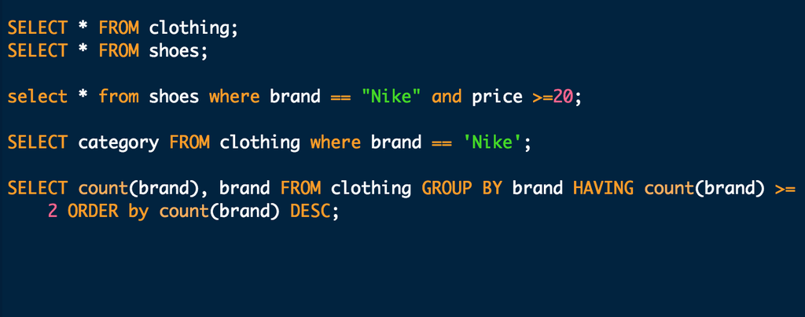

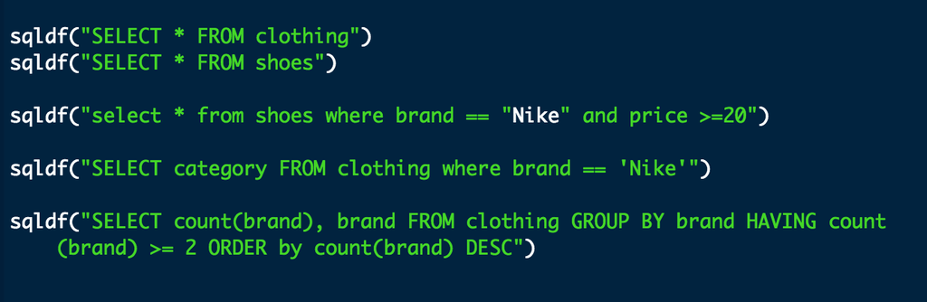

Above is the comparison between simple SQL queries from our example and the same queries used in R with sqldf() package. In essence, if you know SQL this package may come in handy if you find the SQL querying more intuitive than say the “dplyr” package, if not then this is a good starting to learn about the SQL world and all its derivatives. Happy Querying!

# Conclusion

Are you still not convinced that you may want to give SQL a try or SQL in R? It narrows down to preference. Perhaps you are more comfortable with SQL than you are with R and using the “sqldf” improves your efficiency. Perhaps you use R for features that aren’t in SQL but would still like to use some core SQL feature and database keeping. Or Maybe you want to learn SQL and using the “sqldf” package will help you in your journey. The ‘sqldf’ package is a tool that may improve your productivity or simply give a refreshing change to your working environment. There are many parallels between the ‘dplyr’ package and the utility of the ‘sqldf’ package that allow you to pick based off of preference and comfort. That is the beauty of libraries, that they personalize our development experience while facilitating our productivity. Perhaps SQL isn’t for you, but I would encourage you to explore other packages in any programming language you are familiar with. I encourage you to find packages that can be a “replacement” for packages you are currently using; you never know; your productivity might increase or you might find it dreadful but at the end you will have learned to appreciate the power that libraries give to our programming languages.

# Citations

https://github.com/ggrothendieck/sqldf#example-4-join https://docs.oracle.com/javase/tutorial/jdbc/overview/database.html https://www.w3schools.com/sql/ https://www.tutorialspoint.com/sql/ http://www.cs.toronto.edu/~nn/csc309/guide/pointbase/docs/html/htmlfiles/dev_datatypesandconversionsFIN.html https://www.w3schools.com/sql/sql_count_avg_sum.asp https://www.w3schools.com/sql/sql_alias.asp https://www.statmethods.net/management/merging.html https://cran.r-project.org/web/packages/sqldf/README.html#examples https://jasdumas.github.io/tech-short-papers/sqldf_tutorial.html#join_queries https://www.r-bloggers.com/use-sql-to-operate-r-data-frames/